# looOmics: leave-one-out sensitivity analysis for omics differential models

Tanay Belapurkar

2026-11-14

# 1 Purpose

Differential-analysis results on high-dimensional omics data (gene expression, microbiome abundance tables) can be driven by a small number of samples. `looOmics` quantifies this by refitting the model once per left-out sample and measuring how much the coefficients move.

**This is a sensitivity analysis, not a bad-sample detector.** An influential sample may reflect genuine biological heterogeneity — a real subgroup, an extreme but valid responder. Flagged samples should be inspected, not automatically removed.

The package reruns the relevant pipeline for every leave-one-out fit where appropriate: for the DESeq2 engine, for example, size factors and dispersions are re-estimated for every fit.

# 2 Quick start

The recommended interface is a `SummarizedExperiment`. The first example uses a simulated matrix to introduce the workflow; subsequent examples show Bioconductor-native inputs.

```r
library(looOmics)
```

We simulate 200 features, 16 samples, a two-level condition effect on the first 30 features, and one planted influential sample (S09):

```r
set.seed(42)
n_feat <- 200
samples <- sprintf("S%02d", 1:16)
condition <- factor(rep(c("A", "B"), each = 8))
batch <- factor(rep(c("kit1", "kit2"), times = 8))

assay <- matrix(rnorm(n_feat * 16), n_feat, 16,
                dimnames = list(paste0("g", 1:n_feat), samples))
assay[1:30, condition == "B"] <- assay[1:30, condition == "B"] + 1.2

# planted influential sample: S09 (group B) has extreme values on g1-g20
assay[1:20, "S09"] <- assay[1:20, "S09"] + 6

col_data <- data.frame(
    condition = condition, batch = batch,
    depth = round(rnorm(16, mean = 5e6, sd = 4e5)),
    extraction = factor(rep(c("good", "good", "good", "bad"), times = 4)),
    row.names = samples
)
```

## 2.1 Run the leave-one-out analysis

```r
res <- loo_sensitivity(assay, ~ condition + batch, col_data = col_data)
res
```

```
#> LOOResult (engine: lm)
#>   features: 200 | samples: 16 | terms: (Intercept), conditionB, batchkit2
#>   flags: not computed (see flag_influential())
#>   profiles: not computed (see profile_flags())
```

## 2.2 Bioconductor input interoperability

`looOmics` uses `SummarizedExperiment` as its primary Bioconductor input interface. The assay stores features in rows and samples in columns, while `colData` stores the biological and technical sample metadata used both in the differential model and in downstream influence profiling.

```r
se <- SummarizedExperiment::SummarizedExperiment(
    assays = list(logcounts = assay),
    colData = S4Vectors::DataFrame(col_data)
)
res_se <- loo_sensitivity(
    se, ~ condition + batch, engine = "lm",
    assay_name = "logcounts", parallel = FALSE
)
res_se
```

```
#> LOOResult (engine: lm)
#>   features: 200 | samples: 16 | terms: (Intercept), conditionB, batchkit2
#>   flags: not computed (see flag_influential())
#>   profiles: not computed (see profile_flags())
```

For count-based RNA-seq analyses, use raw non-negative integer counts with the DESeq2 engine. The engine reconstructs and refits the DESeq2 workflow for each omitted sample, re-estimating size factors and dispersions rather than rounding or reusing normalized values.

```r
set.seed(21)
count_samples <- sprintf("C%02d", 1:12)
count_condition <- factor(rep(c("control", "treated"), each = 6),
                          levels = c("control", "treated"))
count_meta <- data.frame(condition = count_condition,
                         row.names = count_samples)
count_matrix <- matrix(
    rnbinom(100 * 12, mu = 100, size = 10), nrow = 100,
    dimnames = list(paste0("gene", 1:100), count_samples)
)
count_matrix[1:20, count_condition == "treated"] <-
    count_matrix[1:20, count_condition == "treated"] + 80L
se_counts <- SummarizedExperiment::SummarizedExperiment(
    assays = list(counts = count_matrix),
    colData = S4Vectors::DataFrame(count_meta)
)
res_deseq2 <- loo_sensitivity(
    se_counts, ~ condition, engine = "deseq2",
    assay_name = "counts", parallel = FALSE, fitType = "mean"
)
res_deseq2
```

```
#> LOOResult (engine: deseq2)
#>   features: 100 | samples: 12 | terms: conditiontreated
#>   flags: not computed (see flag_influential())
#>   profiles: not computed (see profile_flags())
```

The `shifts` table records, for every feature, model term, and left-out sample, the full-sample coefficient, the LOO coefficient, the raw shift (`delta`), the standardized deletion shift (`dfbetas`), full and LOO p-values, BH-adjusted q-values, within-term feature ranks, rank changes, and whether the feature’s significance status flipped. A positive `rank_change` means the feature moved to a numerically larger (weaker) rank after sample deletion:

```r
head(tidy(res, what = "shifts"))
```

```
#> # A tibble: 6 × 16
#>   feature term       sample   beta    se   delta dfbetas p_full q_full rank_full
#>   <chr>   <chr>      <chr>   <dbl> <dbl>   <dbl>   <dbl>  <dbl>  <dbl>     <int>
#> 1 g1      (Intercep… S01     1.10  0.925  0.0623  0.0674  0.193  0.952        40
#> 2 g2      (Intercep… S01     0.338 1.07  -0.208  -0.194   0.724  0.983       144
#> 3 g3      (Intercep… S01     0.638 1.00  -0.0634 -0.0632  0.476  0.977        94
#> 4 g4      (Intercep… S01     0.865 0.953 -0.0535 -0.0561  0.314  0.952        66
#> 5 g5      (Intercep… S01    -0.174 1.07   0.133   0.124   0.855  0.983       171
#> 6 g6      (Intercep… S01     0.817 1.06  -0.213  -0.200   0.396  0.965        81
#> # ℹ 6 more variables: p_loo <dbl>, q_loo <dbl>, rank_loo <dbl>,
#> #   rank_change <dbl>, sig_flip <lgl>, error <lgl>
```

For ordinary linear models `dfbetas` coincides with classical DFBETAS; for other engines it is the analogous deletion-based standardized shift.

## 2.3 Flag influential samples

```r
res <- flag_influential(res, method = "topk", k = 2)
res
```

```
#> LOOResult (engine: lm)
#>   features: 200 | samples: 16 | terms: (Intercept), conditionB, batchkit2
#>   flagged influential samples:2/16 (topk)
#>   profiles: not computed (see profile_flags())
```

The planted sample S09 is recovered as the most influential sample:

```r
flags <- tidy(res, what = "flags")
flags[order(-flags$score), ]
```

```
#> # A tibble: 16 × 5
#>    sample score metric      method flagged
#>    <chr>  <dbl> <chr>       <chr>  <lgl>
#>  1 S09    3.24  max_dfbetas topk   TRUE
#>  2 S05    2.24  max_dfbetas topk   TRUE
#>  3 S01    1.62  max_dfbetas topk   FALSE
#>  4 S03    1.53  max_dfbetas topk   FALSE
#>  5 S16    1.53  max_dfbetas topk   FALSE
#>  6 S07    1.52  max_dfbetas topk   FALSE
#>  7 S02    1.29  max_dfbetas topk   FALSE
#>  8 S11    1.19  max_dfbetas topk   FALSE
#>  9 S15    1.15  max_dfbetas topk   FALSE
#> 10 S10    0.945 max_dfbetas topk   FALSE
#> 11 S06    0.932 max_dfbetas topk   FALSE
#> 12 S12    0.930 max_dfbetas topk   FALSE
#> 13 S13    0.912 max_dfbetas topk   FALSE
#> 14 S14    0.833 max_dfbetas topk   FALSE
#> 15 S04    0.802 max_dfbetas topk   FALSE
#> 16 S08    0.708 max_dfbetas topk   FALSE
```

Per-term influence scores show which model terms drive each sample’s score:

```r
head(influence_by_term(res))
```

```
#>          term sample max_abs_shift n_sig_flips
#> 1 (Intercept)    S01     1.6218963           0
#> 2 (Intercept)    S02     0.7641205           0
#> 3 (Intercept)    S03     1.5319187           0
#> 4 (Intercept)    S04     0.4743768           0
#> 5 (Intercept)    S05     2.2414967           0
#> 6 (Intercept)    S06     0.5512234           0
```

## 2.4 Profile flags against metadata

```r
res <- profile_flags(res, model_covariates = c("condition", "batch"))
profiles(res)
```

```
#> FlagProfile: influential-sample metadata profiling
#>   flagged: 2 | not flagged: 14
#>
#> Univariate tests (BH-adjusted):
#>   covariate             test   p_value     p_adj     effect in_model
#>   condition fisher_simulated 1.0000000 1.0000000  0.0000000     TRUE
#>       batch fisher_simulated 0.4666667 0.9333333  0.3779645     TRUE
#>       depth           wilcox 0.2000000 0.8000000 -0.3689640    FALSE
#>  extraction fisher_simulated 1.0000000 1.0000000  0.2182179    FALSE
#>
#> Multivariable model note: too few flagged or unflagged samples for adjusted logistic regression (at least five in each group are required)
```

The profile evaluates associations between flagged status and all selected sample metadata, including the original model variables (`condition` and `batch`) as well as technical variables (`depth` and `extraction`). In-model variables are explicitly labeled. P-values are BH-adjusted across the univariate family; an adjusted logistic model is fit only when the sample size and design support it. Covariates that cannot be tested are reported with reasons rather than silently dropped.

## 2.5 Plot

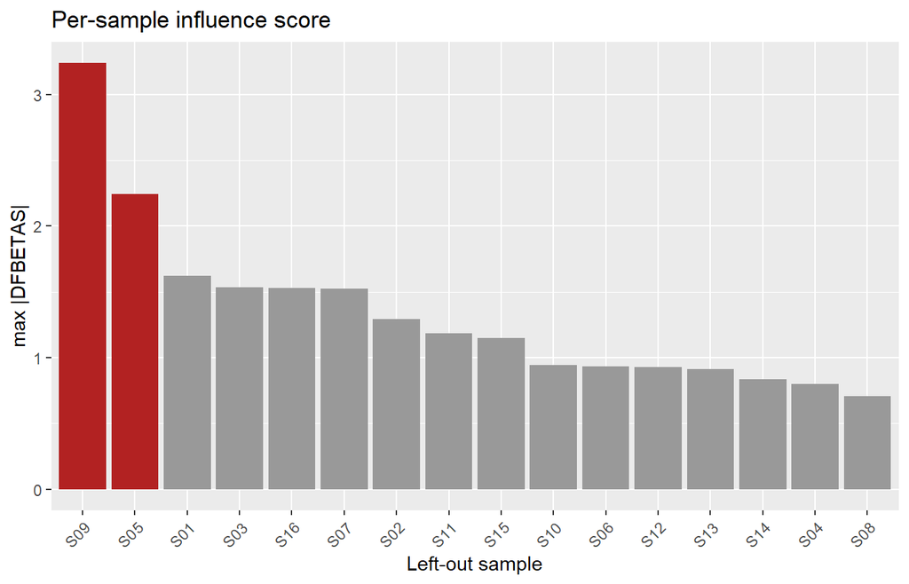

```r
plot(res)
```

# 3 Relationship to existing Bioconductor tools

`limma` and `DESeq2` provide established differential-expression modeling frameworks (Ritchie et al., 2015; Love et al., 2014). `looOmics` does not replace either package: it repeatedly refits these engines after omitting one sample at a time, then compares coefficients, standard errors, adjusted p-values, and within-term feature rankings. It also connects sample influence to biological and technical metadata. This provides an additional sensitivity-analysis layer around existing differential-analysis workflows.

For limma, users should supply appropriately normalized and log-transformed expression values. For DESeq2, users should supply raw integer counts. The package deliberately does not silently convert normalized or transformed values into counts.

# 4 Parallel execution

`looOmics` never changes the `future` plan itself; users control it:

```r
future::plan(future::multisession, workers = 4)
res <- loo_sensitivity(se, ~ condition + batch, engine = "lm")
future::plan(future::sequential)
```

# 5 References

# Appendix

- Love, M. I., Huber, W., and Anders, S. (2014). Moderated estimation of fold change and dispersion for RNA-seq data with DESeq2. *Genome Biology*, 15, 550. [doi:10.1186/s13059-014-0550-8](https://doi.org/10.1186/s13059-014-0550-8).
- Ritchie, M. E., Phipson, B., Wu, D., Hu, Y., Law, C. W., Shi, W., and Smyth, G. K. (2015). limma powers differential expression analyses for RNA-sequencing and microarray studies. *Nucleic Acids Research*, 43(7), e47. [doi:10.1093/nar/gkv007](https://doi.org/10.1093/nar/gkv007).